# Statistical Inference Course Project

Cyril Medabalimi

September 27, 2015

## Overview

In this project you will investigate the exponential distribution in R and compare it with the Central Limit Theorem. The exponential distribution can be simulated in R with rexp(n, lambda) where lambda is the rate parameter. The mean of exponential distribution is 1/lambda and the standard deviation is also 1/lambda. Set lambda = 0.2 for all of the simulations. You will investigate the distribution of averages of 40 exponentials. Note that you will need to do a thousand simulations. We will illustrate via simulation and associated explanatory text the properties of the distribution of the mean of 40 exponentials.To accomplish this, we must: 1. Show the sample mean and compare it to the theoretical mean of the distribution. 2. Show how variable the sample is (via variance) and compare it to the theoretical variance of the distribution. 3. Show that the distribution is approximately normal.

# Sample Mean vs Theoretical Mean

We will run a series of 1000 simulations to create a data set for comparison to theory. Each simulation will contain 40 observations and the expoential distribution function will be set to “rexp(40, 0.2)”.

Known values: lambda = 0.2, n = 40, simulations = 1000

```r
          lambda = 0.2
          n = 40
          nosim = 1000

          set.seed(349)
```

The following code performs the simulations to collect necessary data, then plots the data:

```r
            exp_sim <- function(n, lambda)
            {
                      mean(rexp(n,lambda))
            }

            sim <- data.frame(ncol=2,nrow=1000)
            names(sim) <- c("Index","Mean")

            for (i in 1:nosim)
            {
                      sim[i,1] <- i
                      sim[i,2] <- exp_sim(n,lambda)
            }
```

# Mean of n = 1000

```
## [1] 4.983227
```

# Theoretical exponential mean of exponential distribution

```
## [1] 5
```

The simulation mean of 4.983227 is close to the theoretical value of 5.

Histogram plot of the exponential distribution n = 1000

[figure not shown]

# Sample Variance vs Theoretical Population Variance

We now turn our attention to the variance. We will compare the variance present in the sample means of the 1000 simulations to the theoretical varience of the population.

```
## [1] 0.6010593
```

```
## [1] 0.625
```

[figure not shown]

# Show that the distribution is approximately normal.

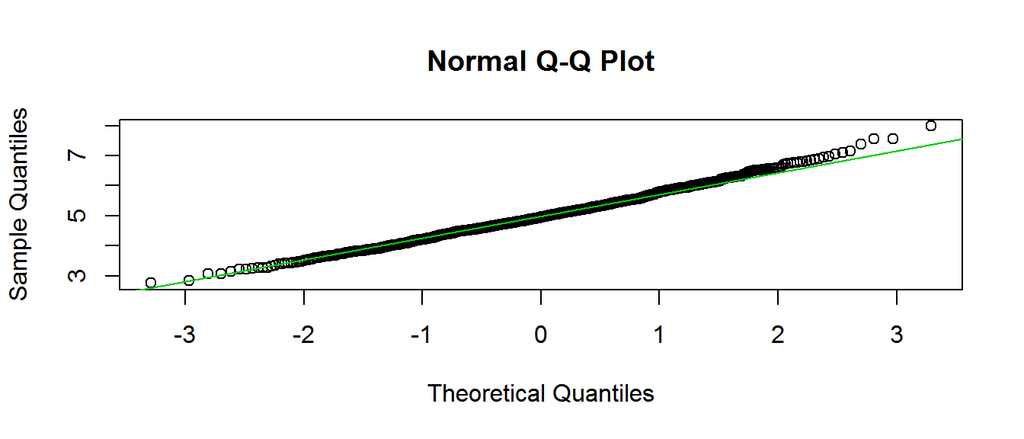

# Appendix

```r
          hist(sim$Mean,
                breaks = 100,
                prob = TRUE,
                main="Exponential Distribution n = 1000",
                xlab="Spread")
                abline(v = theor_mean, col= 3,lwd = 2)
                abline(v = sample_mean, col = 2,lwd = 2)
                legend('topright', c("Sample Mean", "Theoretical Mean"),
                bty = "n",
                lty = c(1,1),
                col = c(col = 3, col = 2))
```

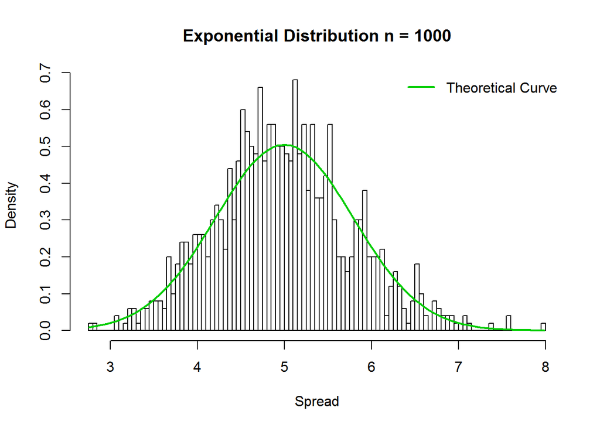

```r
          hist(sim$Mean,
                        breaks = 100,
                        prob = TRUE,
                        main = "Exponential Distribution n = 1000",
                        xlab = "Spread")
                        xfit <- seq(min(sim$Mean), max(sim$Mean), length = 100)
                        yfit <- dnorm(xfit, mean = 1/lambda, sd = (1/lambda/sqrt(40)))
                        lines(xfit, yfit, pch = 22, col = 3, lwd = 2)
                        legend('topright', c("Theoretical Curve"),
                        lty = 1,lwd = 2, bty = "n", col = 3)
```

```r
          hist(sim$Mean,
                        breaks = 100,
                        prob = TRUE,
                        main = "Exponential Distribution n = 1000",
                        xlab = "Spread")
                        lines(density(sim$Mean))
                        abline(v = 1/lambda, col = 3)
                        xfit <- seq(min(sim$Mean), max(sim$Mean), length = 100)
                        yfit <- dnorm(xfit, mean = 1/lambda, sd = (1/lambda/sqrt(40)))
                        lines(xfit, yfit, pch = 22, col = 4, lty = 2)
                        legend('topright', c("Simulated Values", "Theoretical Values"),
                        bty = "n", lty = c(1,2), col = c(4, 3))
```

```r
            qqnorm(sim$Mean,
                            main ="Normal Q-Q Plot")
                            qqline(sim$Mean,
                            col = "3")
```